# Red Wine Exploratory Data Analysis by Vijin

## Understanding if Volatile Acidity along with any other variables other than Alcohol percent influences Quality

### Scatter plot analysis of Volatile acidity vs citric acid, chlorides, free sulfur dioxide, total sulfur dioxide, pH and sulphates and coloring by quality

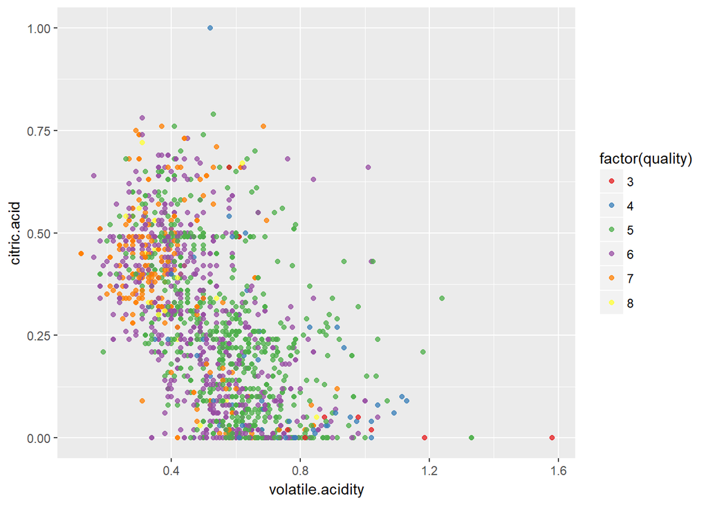

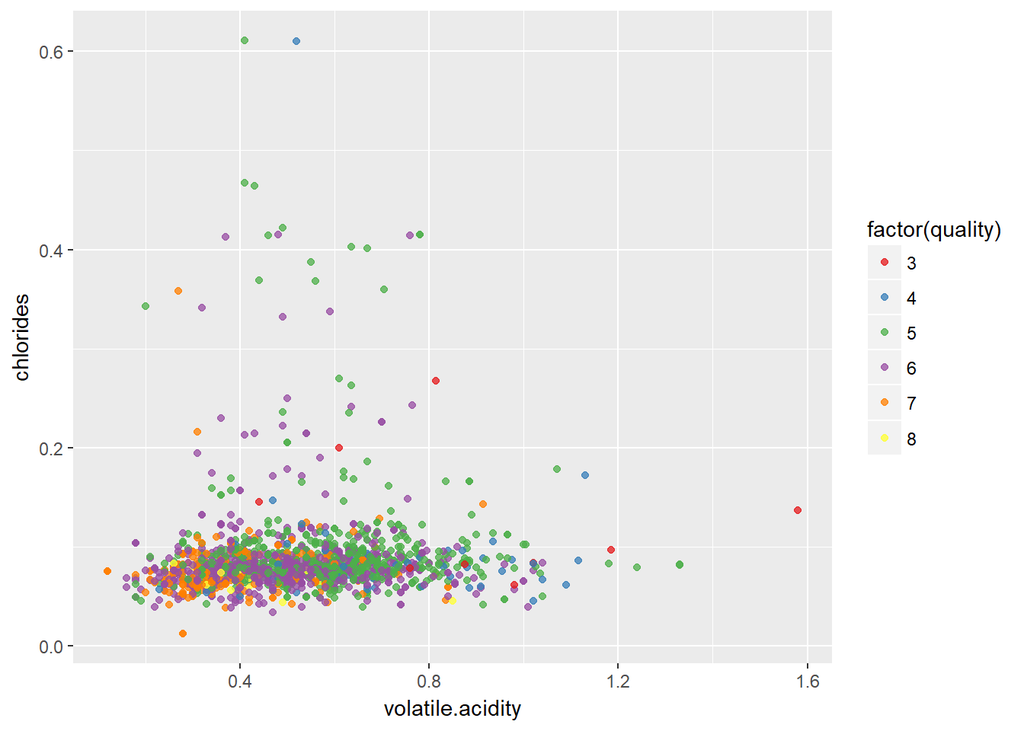

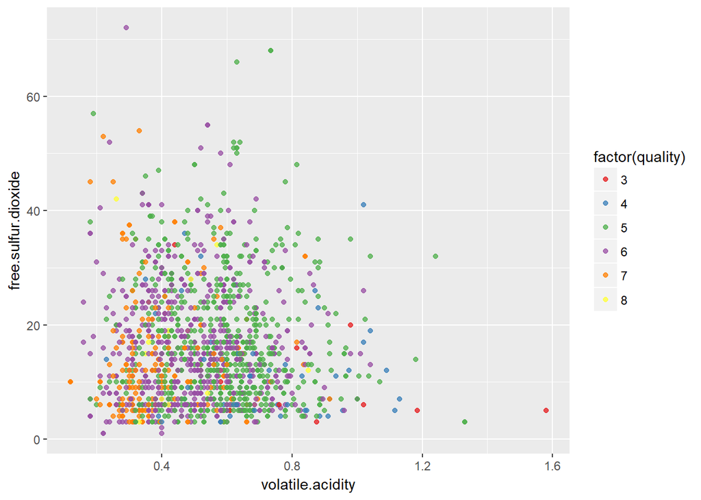

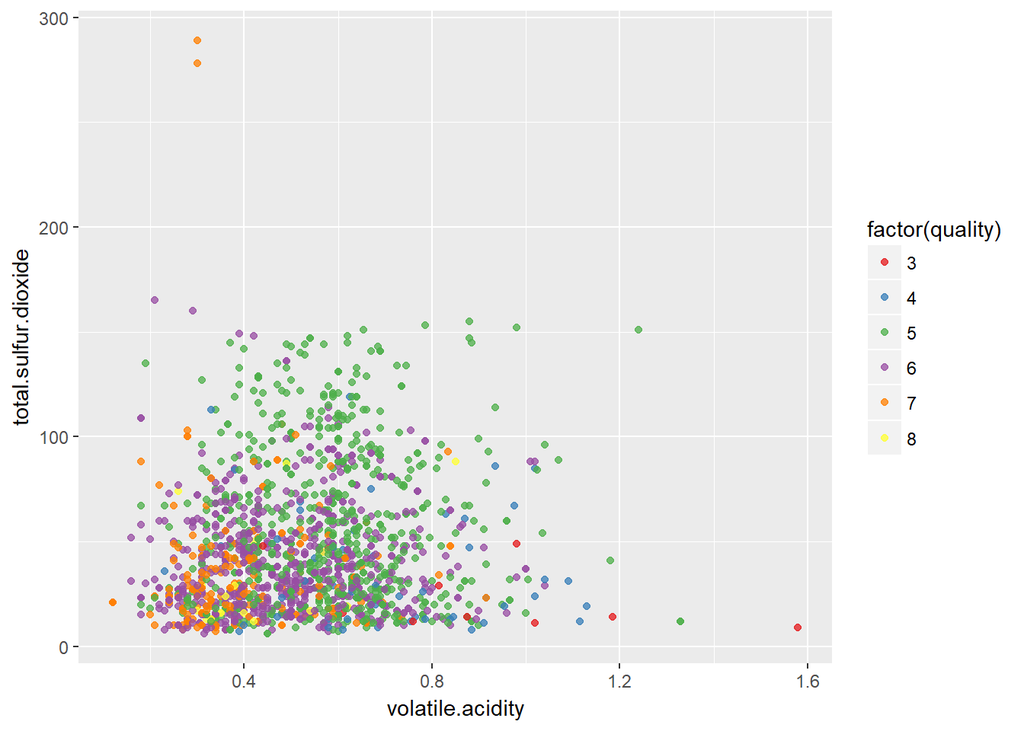

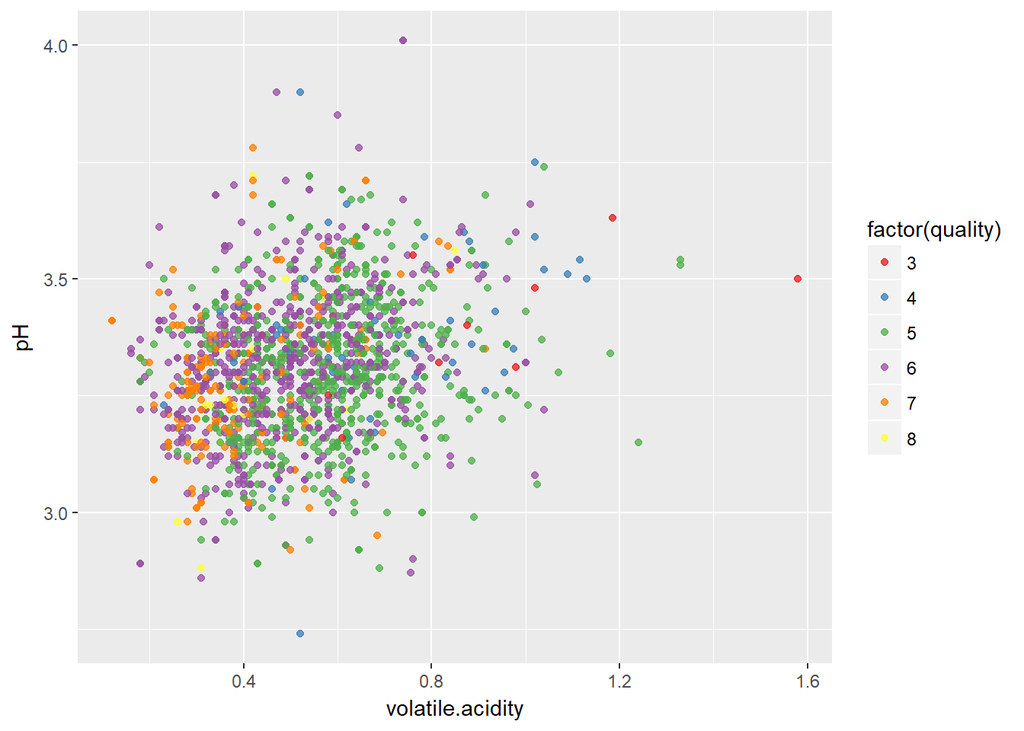

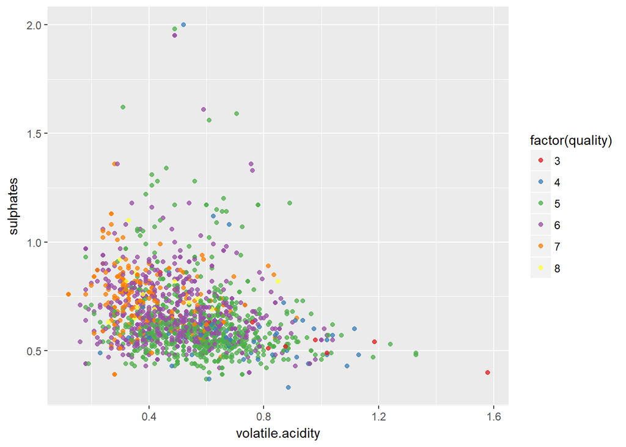

There is some trend between Volatile acidity and citric acid. Example: for lower volatile acidity, higher quality wines have citric acid above 0.25. For higher volatile acidity, higher quaity wines have citric acid below 0.25.

Otherwise, no concrete conclusions can be made by the above scatter plot analysis to establish any relationship.

### Scatter plot analysis of Volatile acidity vs alcohol and coloring it by quality

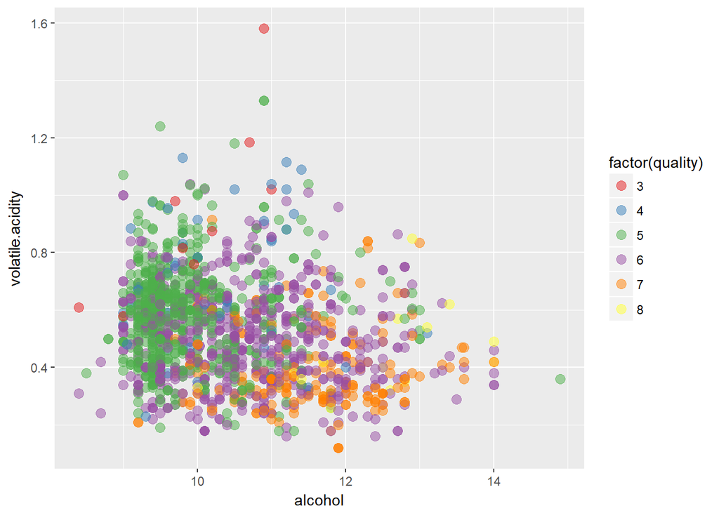

Although, there is no direct relationship between alcohol and volatile acidity, it can be seen that the higher quality wines are clustered towards the lower right side of the plot implying higher alcohol content and lower volatile acidity

## Final Plots and Summary

### Plot for Red Wine Quality distribution (Plot 1)

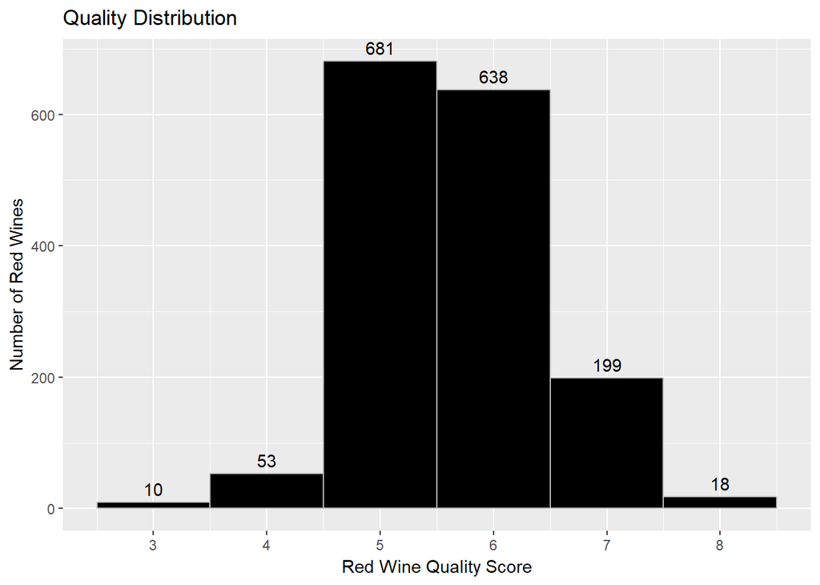

The above plot gives a high level understanding of the overall quality score distribution. It can be seen that majority (82.5%) of the red wines fall in Quality score 5 or 6. Also there are only 10 wines with quality score of 3 and only 18 wines with quality score of 8.

### Correlation matrix plot (Plot 2)

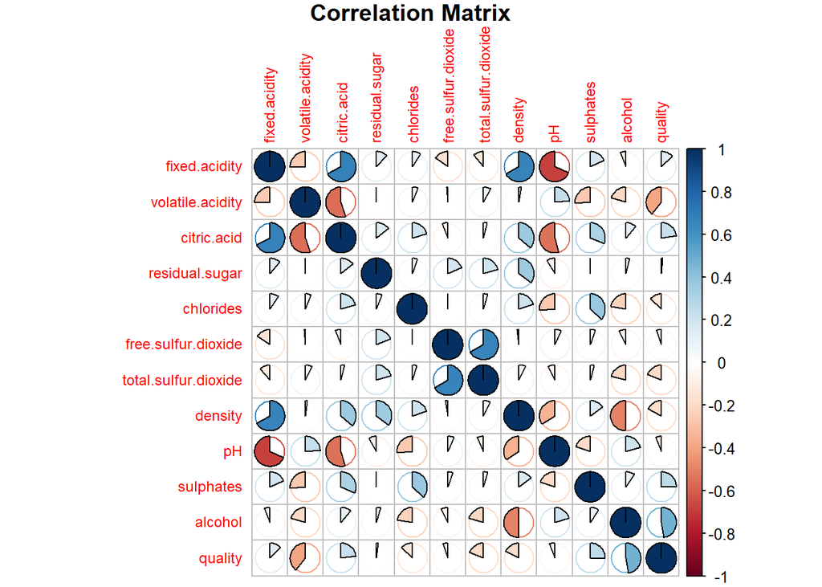

The above matrix plot helped me to understand what variables are closely related to Quality and it could be seen that Alcohol percent(0.48) and Volatile Acidity (-0.4) have a better correlation than the rest of the variables.

### Plotting Mean Alcohol (%) with respect to Quality (Plot 3)

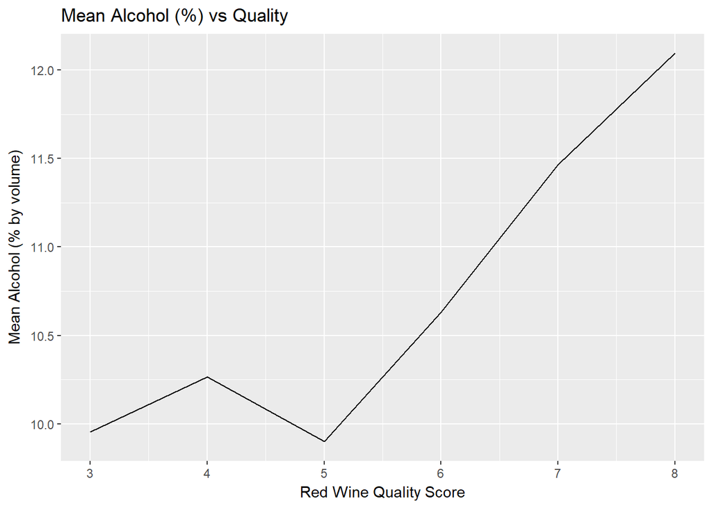

From the above plot it is very clear that for higher quality red wines, the alchol percent is more

### Box plot of Volatile acidity vs Quality (Plot 4)

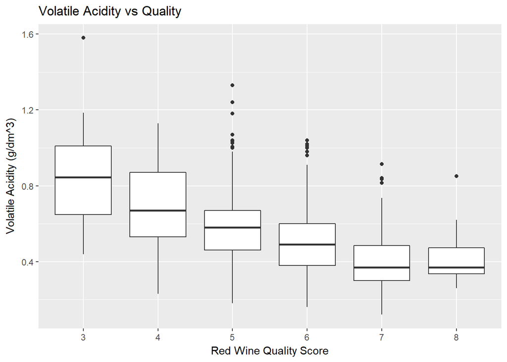

As the quality increases, volatile acidity decreases. As already described in the attribute description that high levels of volatile acidity can lead to an unpleasant taste, the findings through the box plot analysis also corroborate to the same.

### Scatter Plot Analysis of Volatile Acidity vs Alcohol (%) and segregating it by quality (Plot 5)

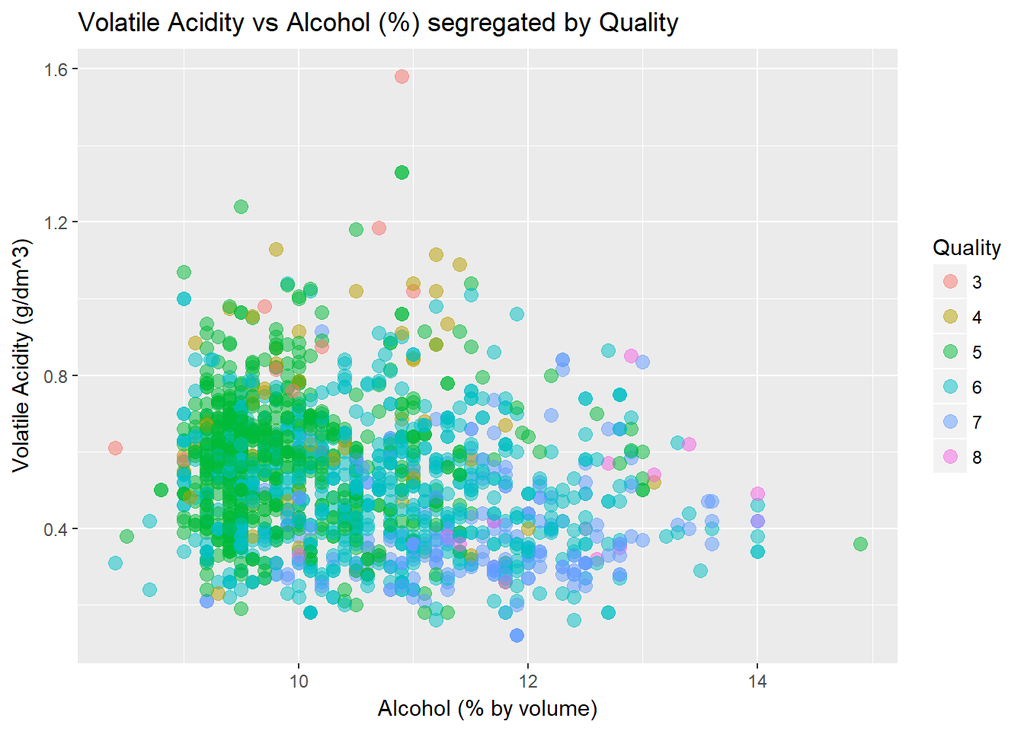

Although, there is no direct relationship between alcohol and volatile acidity, it can be seen that the higher quality wines are clustered towards the lower right side of the plot implying higher alcohol content and lower volatile acidity

## Reflection

### Challenges and how I overcame them

Completing this project was an intense learning exercise which helped me to review all the concepts that I had learnt in Exploratory Data Analysis module and also some additional concepts which weren’t taught as well. One of the major challenges I encountered during the course of this project is to identify those key variables which could affect the quality of red wine. As seen from Correlation matrix, there wasn’t a very strong correlation between any of the variables and I had to choose 2 variables which had atleast some correlation so that I could proceed ahead with my analysis. During graphing of the plots for correlation matrix, I was finding it difficult to represent the correlation between different variables in an effective manner. That is when I came across an interesting package called corrplot which was very helpful in identfying correlation between different variables. Also, I had to do some good research on how I could generate data labels in a distribution graph as shown in Plot 1.

### How can the analysis be enriched

Currently, the data provided to us is soley dependent on the chemical properties of the wine. There could be other external factors as well which could impact the quality of wine; for example - the quality of grapes used to prepare the wine, the duration/storage time, the temperature in which the wine was stored, etc. Also, the price of wine could also help us in deciding the quality of wine to an extent.Finally, we also need to understand the factors wine expert considered when scoring the wines.

#### References:

1. https://rpubs.com/seslezak/color_schemes - Color Schemes
2. https://rstudio-pubs-static.s3.amazonaws.com/240657_5157ff98e8204c358b2118fa69162e18.html - Corrplot
3. https://www.statmethods.net/stats/correlations.html - Correlations
4. https://www.datacamp.com/community/blog/r-correlation-tutorial - Correlation 5)https://stackoverflow.com/questions/40509217/how-to-have-r-corrplot-title-position-correct - Corrplot title position
5. https://stackoverflow.com/questions/30057765/histogram-ggplot-show-count-label-for-each-bin-for-each-category - Adding data label for goem_hist